# PTT C_Chat

Tu hao wei

2018/10/17

# 介紹

使用並修改老師的程式，對PTT的C_Chat版分析，時間從2018-10-9凌晨左右至2018-10-17中午。

下面幾篇文章可能影響結果

```
作者mistel (Mistel)
看板C_Chat
標題[討論] 化學系真的會在實驗室拿燒杯煮咖啡嗎？
時間Sun Oct 14 12:01:37 2018
發信站: 批踢踢實業坊(ptt.cc), 來自: 223.137.97.110
文章網址: https://www.ptt.cc/bbs/C_Chat/M.1539489699.A.933.html
```

```
作者forsakesheep (歐洲羊)
看板C_Chat
標題[討論] 從2000年到現在還有在寫作的輕小說家
時間Tue Oct  9 23:51:55 2018
發信站: 批踢踢實業坊(ptt.cc), 來自: 111.242.192.49
文章網址: https://www.ptt.cc/bbs/C_Chat/M.1539100318.A.AF9.html
```

# 開始

1.載入packages

```r
library(bitops)
library(httr)
library(RCurl)
library(XML)
library(tm)
library(NLP)
library(tmcn)
library(jiebaRD)
library(jiebaR)
```

2.PTT爬蟲，將需要的資料抓下來，並按照日期分成不同檔案

```r
#get the website url of all the article from every pages
from <- 17412 # 2018-10-10
to   <- 17550 # 2018-10-17
prefix = "https://www.ptt.cc/bbs/C_Chat/index"
data <- list()
for( id in c(from:to) )
{
  url  <- paste0( prefix, as.character(id), ".html" )
  html <- htmlParse( GET(url) )
  url.list <- xpathSApply( html, "//div[@class='title']/a[@href]", xmlAttrs )
  data <- rbind( data, as.matrix(paste('https://www.ptt.cc', url.list, sep='')) )
}
data <- unlist(data)
head(data)

#get all the context, and sort them by date
library(dplyr)
getdoc <- function(url)
{
  html <- htmlParse( getURL(url) )
  doc  <- xpathSApply( html, "//div[@id='main-content']", xmlValue )
  time <- xpathSApply( html, "//*[@id='main-content']/div[4]/span[2]", xmlValue )
  temp <- gsub( "  ", " 0", unlist(time) )
  part <- strsplit( temp, split=" ", fixed=T )
  #part form like -> "Tue"      "Oct"      "09"       "23:43:27" "2018"
  date <- part[[1]][3]
  day <- part[[1]][1]
  #print(date and dat)
  name <- paste0('./DATA/', date, "__", day, ".txt")
  write(doc, name, append = TRUE)
}
test.data <- data[1:1058]
sapply(test.data, getdoc)
#structure of data[1059] is not as same as the others
#https://www.ptt.cc/bbs/C_Chat/M.1539346213.A.3D3.html
test.data = data[1060:1437]
sapply(test.data, getdoc)

#structure of data[1438] is not as same as the others
#https://www.ptt.cc/bbs/C_Chat/M.1539438107.A.869.html
test.data <- data[1439:2724]
sapply(test.data, getdoc)

#cannot opent data[2161]
#https://www.ptt.cc/bbs/C_Chat/M.1539603620.A.E09.html
test.data <- data[2162:2724]
sapply(test.data, getdoc)

#stop at data[2311]
#https://www.ptt.cc/bbs/C_Chat/M.1539645748.A.C76.html
test.data <- data[2311:2724]
sapply(test.data, getdoc)

#stop at data[2724]
#https://www.ptt.cc/bbs/C_Chat/M.1539747042.A.B75.html
```

3.建立Corpus並清洗

```r
#cleaning and add new words
d.corpus <- Corpus( DirSource("./DATA") )
toSpace <- content_transformer(function(x, pattern) {
  return (gsub(pattern, " ", x))
})

d.corpus <- tm_map(d.corpus, toSpace, "　")
d.corpus <- tm_map(d.corpus, toSpace, "︳")
d.corpus <- tm_map(d.corpus, toSpace, "・")
d.corpus <- tm_map(d.corpus, toSpace, "ー")
d.corpus <- tm_map(d.corpus, toSpace, "小說")
d.corpus <- tm_map(d.corpus, toSpace, "覺得")
d.corpus <- tm_map(d.corpus, toSpace, "可以")
d.corpus <- tm_map(d.corpus, toSpace, "沒有")
d.corpus <- tm_map(d.corpus, toSpace, "就是")
d.corpus <- tm_map(d.corpus, toSpace, "標題")
d.corpus <- tm_map(d.corpus, toSpace, "編輯")
d.corpus <- tm_map(d.corpus, toSpace, "發信站")
d.corpus <- tm_map(d.corpus, toSpace, "批踢踢實業坊")
d.corpus <- tm_map(d.corpus, toSpace, "自己")
d.corpus <- tm_map(d.corpus, toSpace, "應該")
d.corpus <- tm_map(d.corpus, toSpace, "知道")
d.corpus <- tm_map(d.corpus, toSpace, "真的")
d.corpus <- tm_map(d.corpus, toSpace, "不會")
d.corpus <- tm_map(d.corpus, toSpace, "動畫")
d.corpus <- tm_map(d.corpus, toSpace, "不是")
d.corpus <- tm_map(d.corpus, toSpace, "只是")
d.corpus <- tm_map(d.corpus, toSpace, "所以")
d.corpus <- tm_map(d.corpus, toSpace, "不會")

d.corpus <- tm_map(d.corpus, toSpace, "pttcc")
d.corpus <- tm_map(d.corpus, toSpace, "CChat")
d.corpus <- tm_map(d.corpus, toSpace, "enfis")
d.corpus <- tm_map(d.corpus, toSpace, "Wed")
d.corpus <- tm_map(d.corpus, toSpace, "Thu")
d.corpus <- tm_map(d.corpus, toSpace, "Fri")
d.corpus <- tm_map(d.corpus, toSpace, "Sat")
d.corpus <- tm_map(d.corpus, toSpace, "Sun")
d.corpus <- tm_map(d.corpus, toSpace, "Mon")
d.corpus <- tm_map(d.corpus, toSpace, "Tue")
d.corpus <- tm_map(d.corpus, toSpace, "Wed")
d.corpus <- tm_map(d.corpus, toSpace, "dukemon")#person's ID


d.corpus <- tm_map(d.corpus, removePunctuation)
d.corpus <- tm_map(d.corpus, removeNumbers)
```

4.建立詞庫(2018秋季動畫詞庫)

```r
mixseg = worker()
new_user_word(mixseg,'哥布林',"n")
```

```
## [1] TRUE
```

```r
new_user_word(mixseg,'哥殺',"n")
```

```
## [1] TRUE
```

```r
new_user_word(mixseg,'哥布林殺手',"n")
```

```
## [1] TRUE
```

```r
new_user_word(mixseg,'魔禁',"n")
```

```
## [1] TRUE
```

```r
new_user_word(mixseg,'魔法禁書目錄',"n")
```

```
## [1] TRUE
```

```r
new_user_word(mixseg,'提拉米斯',"n")
```

```
## [1] TRUE
```

```r
new_user_word(mixseg,'魔導少年',"n")
```

```
## [1] TRUE
```

```r
new_user_word(mixseg,'妖尾',"n")
```

```
## [1] TRUE
```

```r
new_user_word(mixseg,'妖精的尾巴',"n")
```

```
## [1] TRUE
```

```r
new_user_word(mixseg,'電光超人',"n")
```

```
## [1] TRUE
```

```r
new_user_word(mixseg,'繽紛世界',"n")
```

```
## [1] TRUE
```

```r
new_user_word(mixseg,'青春豬頭少年',"n")
```

```
## [1] TRUE
```

```r
new_user_word(mixseg,'終將成為妳',"n")
```

```
## [1] TRUE
```

```r
new_user_word(mixseg,'莉茲與青鳥',"n")
```

```
## [1] TRUE
```

```r
new_user_word(mixseg,'逆轉裁判',"n")
```

```
## [1] TRUE
```

```r
new_user_word(mixseg,'弦音',"n")
```

```
## [1] TRUE
```

```r
new_user_word(mixseg,'佐賀偶像',"n")
```

```
## [1] TRUE
```

```r
new_user_word(mixseg,'莉茲與青鳥',"n")
```

```
## [1] TRUE
```

5.進行斷詞，並依照日期建立文本矩陣 TermDocumentMatrix

```r
jieba_tokenizer = function(d)
{
  unlist( segment(d[[1]], mixseg) )
}
seg = lapply(d.corpus, jieba_tokenizer)

count_token = function(d)
{
  as.data.frame(table(d))
}
tokens = lapply(seg, count_token)

n = length(seg)
TDM = tokens[[1]]
colNames <- names(seg)
colNames <- gsub(".txt", "", colNames)
for( id in c(2:n) )
{
  TDM = merge(TDM, tokens[[id]], by="d", all = TRUE)
  names(TDM) = c('d', colNames[1:id])
}
TDM[is.na(TDM)] <- 0
#take out
TDM$d <- as.character(TDM$d)
TDM <- TDM[nchar(TDM$d)>1,]#去除字數是1的詞
library(knitr)
kable(head(TDM))
```

|  | d | 09__Tue | 10__Wed | 11__Thu | 12__Fri | 13__Sat | 14__Sun | 15__Mon | 16__Tue | 17__Wed | NA__belmontc | NA__DsLove710 | NA__GOBS | NA__hoshiakari | NA__laigeorge89 | NA__madboy | NA__Roentgenium | NA__Ruin0019 | NA__s32244153 | NA__staristic |
| --- | --- | --- | --- | --- | --- | --- | --- | --- | --- | --- | --- | --- | --- | --- | --- | --- | --- | --- | --- | --- |
| 2 | 阿光 | 1 | 0 | 1 | 0 | 0 | 0 | 0 | 0 | 0 | 0 | 0 | 0 | 0 | 0 | 0 | 0 | 0 | 0 | 0 |
| 3 | 阿Q | 1 | 2 | 1 | 0 | 2 | 3 | 0 | 0 | 0 | 0 | 0 | 0 | 0 | 0 | 0 | 0 | 0 | 0 | 0 |
| 5 | 哀傷 | 1 | 1 | 0 | 2 | 0 | 1 | 0 | 1 | 0 | 0 | 0 | 0 | 0 | 0 | 0 | 0 | 0 | 0 | 0 |
| 8 | 愛的 | 1 | 10 | 7 | 12 | 6 | 4 | 2 | 2 | 2 | 0 | 0 | 0 | 0 | 0 | 0 | 0 | 0 | 0 | 0 |
| 9 | 愛搞 | 3 | 0 | 1 | 1 | 0 | 2 | 0 | 0 | 0 | 0 | 0 | 0 | 0 | 0 | 0 | 0 | 0 | 0 | 0 |
| 10 | 愛錢的 | 1 | 0 | 0 | 0 | 0 | 0 | 0 | 0 | 0 | 0 | 0 | 0 | 0 | 0 | 0 | 0 | 0 | 0 | 0 |

```r
kable(tail(TDM))
```

|  | d | 09__Tue | 10__Wed | 11__Thu | 12__Fri | 13__Sat | 14__Sun | 15__Mon | 16__Tue | 17__Wed | NA__belmontc | NA__DsLove710 | NA__GOBS | NA__hoshiakari | NA__laigeorge89 | NA__madboy | NA__Roentgenium | NA__Ruin0019 | NA__s32244153 | NA__staristic |
| --- | --- | --- | --- | --- | --- | --- | --- | --- | --- | --- | --- | --- | --- | --- | --- | --- | --- | --- | --- | --- |
| 111841 | Lguf | 0 | 0 | 0 | 0 | 0 | 0 | 0 | 0 | 0 | 0 | 0 | 0 | 0 | 0 | 0 | 0 | 0 | 0 | 10 |
| 111842 | Lhug | 0 | 0 | 0 | 0 | 0 | 0 | 0 | 0 | 0 | 0 | 0 | 0 | 0 | 0 | 0 | 0 | 0 | 0 | 10 |
| 111843 | Lu | 0 | 0 | 0 | 0 | 0 | 0 | 0 | 0 | 0 | 0 | 0 | 0 | 0 | 0 | 0 | 0 | 0 | 0 | 40 |
| 111844 | rf | 0 | 0 | 0 | 0 | 0 | 0 | 0 | 0 | 0 | 0 | 0 | 0 | 0 | 0 | 0 | 0 | 0 | 0 | 2 |
| 111845 | rg | 0 | 0 | 0 | 0 | 0 | 0 | 0 | 0 | 0 | 0 | 0 | 0 | 0 | 0 | 0 | 0 | 0 | 0 | 8 |
| 111846 | Touhou | 0 | 0 | 0 | 0 | 0 | 0 | 0 | 0 | 0 | 0 | 0 | 0 | 0 | 0 | 0 | 0 | 0 | 0 | 2 |

6.TDM -> TF-IDF

```r
tf <- apply(as.matrix(TDM[,2:(n+1)]), 2, sum)

library(Matrix)
idfCal <- function(word_doc)
{
  log2( n / nnzero(word_doc) )
}
idf <- apply(as.matrix(TDM[,2:(n+1)]), 1, idfCal)

doc.tfidf <- TDM

tempY = matrix(rep(c(as.matrix(tf)), each = length(idf)), nrow = length(idf))
tempX = matrix(rep(c(as.matrix(idf)), each = length(tf)), ncol = length(tf), byrow = TRUE)
doc.tfidf[,2:(n+1)] <- (doc.tfidf[,2:(n+1)] / tempY) * tempX

stopLine = rowSums(doc.tfidf[,2:(n+1)])
delID = which(stopLine == 0)

kable(head(doc.tfidf[delID,1]))
```

| x |
| --- |
| 來自 |
| 網址 |
| 文章 |
| pttcc |

```r
kable(tail(doc.tfidf[delID,1]))
```

| x |
| --- |
| 來自 |
| 網址 |
| 文章 |
| pttcc |

```r
TDM = TDM[-delID,]
doc.tfidf = doc.tfidf[-delID,]
```

7.取得關鍵字

```r
TopWords = data.frame()
for( id in c(1:n) )
{
  dayMax = order(doc.tfidf[,id+1], decreasing = TRUE)
  showResult = t(as.data.frame(doc.tfidf[dayMax[1:5],1]))
  TopWords = rbind(TopWords, showResult)
}
rownames(TopWords) = colnames(doc.tfidf)[2:(n+1)]
TopWords <- TopWords[1:9,]
TopWords = droplevels(TopWords)
kable(TopWords)
```

|  | V1 | V2 | V3 | V4 | V5 |
| --- | --- | --- | --- | --- | --- |
| 09__Tue | peco | evas | 哥布林 | 宮部 | 上遠野 |
| 10__Wed | 哥布林 | 哥殺 | 還是 | 比較 | 一個 |
| 11__Thu | 哥布林 | 比較 | 還是 | 一個 | 什麼 |
| 12__Fri | 哥布林 | 哥殺 | 什麼 | 還是 | 如果 |
| 13__Sat | 哥布林 | 還是 | 哥殺 | 什麼 | TED |
| 14__Sun | 哥布林 | 燒杯 | 哥殺 | 還是 | 什麼 |
| 15__Mon | 哥布林 | 哥殺 | 遊戲 | 什麼 | 還是 |
| 16__Tue | 哥布林 | 哥殺 | deathly | 免費 | 問題 |
| 17__Wed | 白鷹 | Lance | 比較 | 開始 | 最後 |

10/9的資料因為只有取一點點而已，所以不太能構成參考 10/9會出現宮部和上遠野的原因應該是此報告最前方的一篇討論–“從2000年到現在還有在寫作的輕小說家”。 此篇內容出現日本小說家宮部美幸、上遠野浩平。 10/9中的peco是為動畫【乒乓】的主角之一，應該是取資料時取到了討論【乒乓】的文章。

10/14出現的燒杯也是因為一篇用燒杯煮咖啡的文章，加上後續討論，讓其出現在關鍵字中

至於常出現的非垃圾字有哥布林和哥殺，都是和本季動畫【哥布林殺手】有關的關鍵字，由此可見，【哥布林殺手】的討論度是很高的。

8.用取得的關鍵字將TDM視覺化

```r
AllTop = as.data.frame( table(as.matrix(TopWords)) )
AllTop = AllTop[order(AllTop$Freq, decreasing = TRUE),]

kable(head(AllTop))
```

|  | Var1 | Freq |
| --- | --- | --- |
| 3 | 哥布林 | 8 |
| 4 | 哥殺 | 6 |
| 6 | 還是 | 6 |
| 12 | 什麼 | 5 |
| 2 | 比較 | 3 |
| 14 | 一個 | 2 |

[figure not shown]

```r
TopNo = 5
tempGraph = data.frame()
for( t in c(1:TopNo) )
{
  word = matrix( rep(c(as.matrix(AllTop$Var1[t])), each = n), nrow = n )
  temp = cbind( colnames(doc.tfidf)[2:(n+1)], t(TDM[which(TDM$d == AllTop$Var1[t]), 2:(n+1)]), word )
  colnames(temp) = c("date", "freq", "words")
  tempGraph = rbind(tempGraph, temp)
  names(tempGraph) = c("date", "freq", "words")
}

library(ggplot2)
library(varhandle)
tempGraph$freq = unfactor(tempGraph$freq)
par(family=("Heiti TC Light")) #已經加了這一行，不知為何字顯示出來還是框框
ggplot(tempGraph, aes(date, freq)) +
  geom_point(aes(color = words, shape = words), size = 5) +
  geom_line(aes(group = words, linetype = words)) +
  theme(axis.text.x = element_text(angle = 90, hjust = 1))
```

```r
kable(tail(AllTop))
```

|  | Var1 | Freq |
| --- | --- | --- |
| 16 | 最後 | 1 |
| 17 | deathly | 1 |
| 18 | evas | 1 |
| 19 | Lance | 1 |
| 20 | peco | 1 |
| 21 | TED | 1 |

9.發文時間與發文量的關係作圖

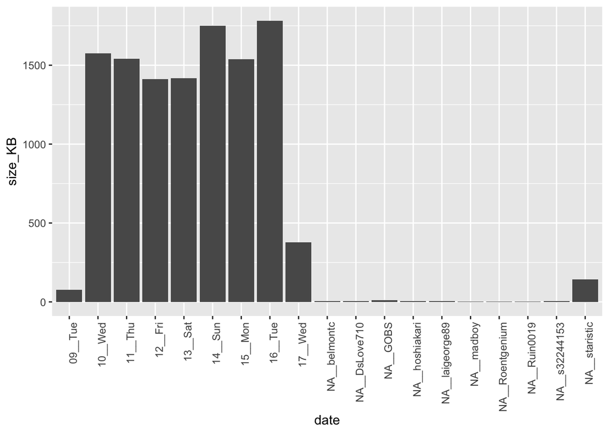

```r
filenames = as.array(paste0("./DATA/",colnames(doc.tfidf)[2:(n+1)],".txt"))
sizeResult = apply(filenames, 1, file.size) / 1024
showSize = data.frame(colnames(doc.tfidf)[2:(n+1)], sizeResult)
names(showSize) = c("date", "size_KB")

ggplot(showSize, aes(x = date, y = size_KB)) + geom_bar(stat="identity")+
  theme(axis.text.x = element_text(angle = 90, hjust = 1))
```

原本預期假日的發文的資料量會最大，但其實沒有。 我想是因為我是以發文的日期做檔案分割，但回文的日期可以和發文的日期錯開，所以無法看出明確差距